# Basic Linear Regression Models

Robert I. Colautti

# Data

In this tutorial, we’ll be using data from a meta-analysis by Colautti & Lau (2015) in Molecular Ecology. [Paper Link](https://onlinelibrary.wiley.com/doi/abs/10.1111/mec.13162)

Data from the paper are available on the Dryad database: https://doi.org/10.5061/dryad.gt678

Data from several analyses are available. We’ll be analyzing data from Figure 1, which is a meta-analysis of plant traits.

```r
TraitDat<-read.csv("https://datadryad.org/bitstream/handle/10255/dryad.82837/MetaPCA_Data.csv?sequence=1")

# Save a local copy for future analysis
write.csv(TraitDat,"TraitDat.csv",row.names=F)
```

```r
str(TraitDat)
```

```
## 'data.frame':    298 obs. of  7 variables:
##  $ Reference: Factor w/ 34 levels "astlova and Kv?t (2002)",..: 2 8 19 23 33 11 26 16 27 13 ...
##  $ Species  : Factor w/ 23 levels "Alliaria petiolata",..: 1 1 6 8 10 12 16 18 18 20 ...
##  $ Trait    : Factor w/ 6 levels "defence","growth",..: 1 1 1 1 1 1 1 1 1 1 ...
##  $ Garden   : int  1 1 1 1 1 1 1 1 1 1 ...
##  $ Range    : Factor w/ 2 levels "I","N": 1 1 1 1 1 1 1 1 1 1 ...
##  $ PC1SD    : num  0.54 1.477 0.735 2.422 1.885 ...
##  $ LatSD    : num  1.467 0.409 1.609 1.641 3.567 ...
```

Data for the meta-analysis are from common garden experiments. As detailed in the paper, common garden experiments grow plants from different genetic groups (e.g. seed family, population) in the same environment to look for genetic differences. In this study, we were interested in comparing native and introduced populations.

1. **Reference** is the paper from which the original data were taken
2. **Species** is the species on which the traits were measured
3. **Trait** is the trait measured (actually a class of related traits, see PC1SD)
4. **Garden** is a code for the common garden used
5. **Range** indicates whether the population value is calculated among native (N) or introduced (I) populations
6. **PC1SD** this is the variance among population means – a measure of genetic variation for the **Trait** specified in column 3. This is actually the first principal component of a number of related traits. Principal components analysis is covered in another tutorial.
7. **LatSD** is the variance among population latitudes – a measure of geographic distribution of the genotypes

# Theory

A simple linear model describes a relationship between one or more **predictor** (a.k.a. **independent**) variables and a **response** (a.k.a. **dependent**) variable. In mathematical terms:

$$Y \sim f(X) + \epsilon$$

where $Y$ is a *vector* containing the *response* variable and $f(X)$ is a linear combination one or more *vectors* representing the *predictor* variables. The ‘epsilon’ character ($\epsilon$) is the ‘error’ of the model – that is, variation in $Y$ that is not explained by $f(X)$. For example, with two predictors $X_1$ and $X_2$, a simple linear function is:

$$Y = \beta_0 + \beta_1 X_1 + \beta_2 X_2 + \epsilon$$

# Simulations

A good way to understand this model is to simulate data. Start by making vectors of random values for each predictor variable $X$. In this case, we’ll make one continuous variable $X_c$ and one factoral variable $X_f$.

```r
X_c<-rnorm(1000)
X_f<-sample(c(0,1),1000,replace=T)
```

Note that we have encoded $X_f$ numerically as 0 and 1. We’ll come back to this point later when we look at the `lm` function. If it’s not obvious from the code, you can use `qplot()` from the `ggplot2` library to investigate the distributions of the independent variables:

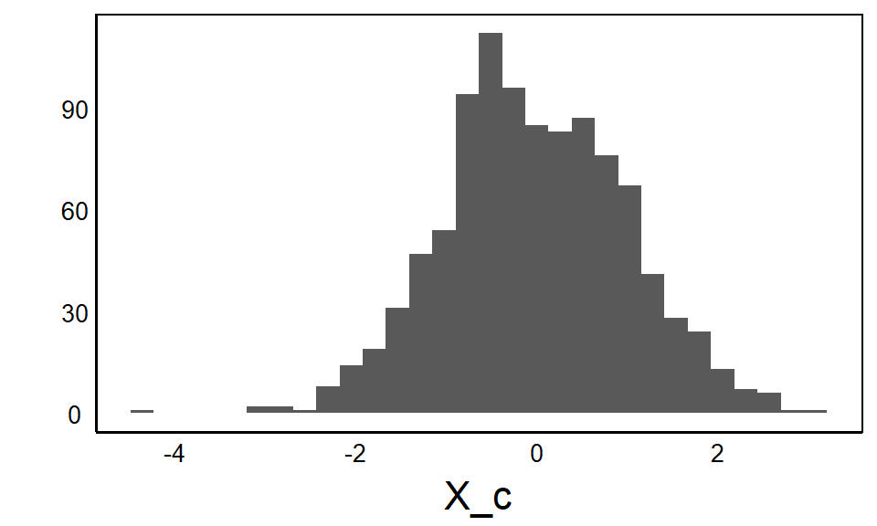

```r
qplot(X_c)
```

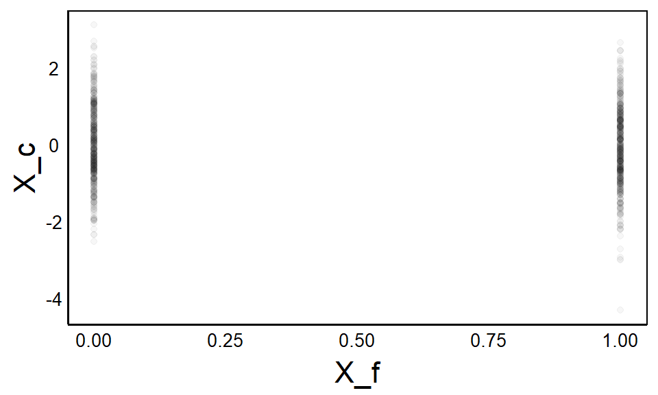

```r
qplot(X_f,X_c, alpha=I(0.03))
```

Next, we add the error term $\epsilon$ to model the variation in $Y$ that is not explained by $X_f$ or $X_c$. Let’s assume that error variance is normally distributed with a mean of zero and standard deviation of 1:

```r
Error<-rnorm(1000)
```

Finally, we make the response variable $Y$ as a linear function $f(X)$ of $X_c$ and $X_f$ and the error term $\epsilon$. In this example, $\beta_0 = 500$ , $\beta_1 = 10$ , and $\beta_2 = 2$:

```r
Y<-500 + 10*X_c + 2*X_f + Error
```

and plot:

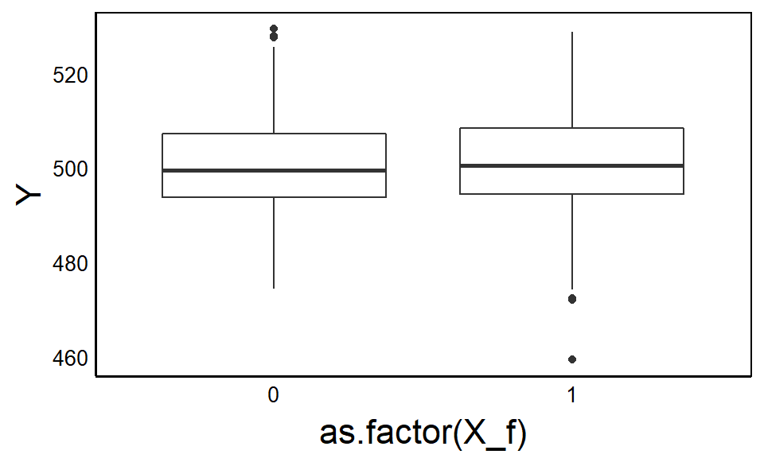

```r
qplot(as.factor(X_f),Y,geom="boxplot")
```

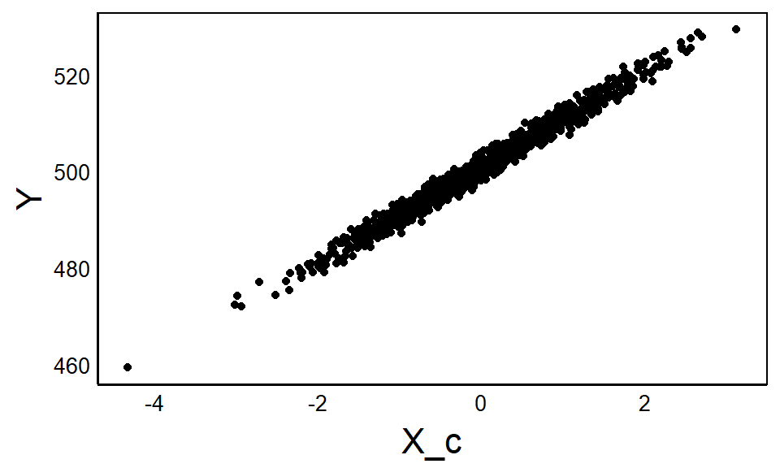

```r
qplot(X_c,Y)
```